# Report on study `McQuillan_2020` from

# Trait measurements

## Overview

The dataset includes 157 individual data points from 8 taxa, with data included for the following 3 traits:

| trait_name | taxa | records | records_per_taxa |
| --- | --- | --- | --- |
| leaf_C_per_dry_mass | 8 | 52 | 6.50 |
| leaf_N_per_dry_mass | 8 | 52 | 6.50 |
| leaf_P_per_dry_mass | 8 | 53 | 6.62 |

**Question:** (section `traits`) Does this study include other trait data we may have missed?

**Question:** (section `traits`) Were any of your data sourced from other studies? If so, can you tell us which records and the source (so that we can avoid duplicates, where possible)?

All data passed quality control so nothing was excluded in this study. (Yay!)

## Numerical traits

We have recorded the following traits with continuous numerical values in this dataset. Plots are shown comparing the distribution of values in your study (blue) to those in other datasets within AusTraits (red, green). For each trait, please eyeball the information provided and let us know of any issues or updates where appropriate.

### leaf_C_per_dry_mass

We aligned the contributed variable called `C (%)` in the data you supplied with the trait `leaf_C_per_dry_mass` in the AusTraits database, with value_types `raw`.

The original variable was supplied with units `%`; these were converted to our standard `mg/g`.

The data has the following properties:

- **standardised name**: leaf_C_per_dry_mass
- **standardised description**: The ratio [PATO:0001470] of the mass [PATO:0000125] of carbon [CHEBI:27594] in a leaf [PO:0025034] to leaf dry mass [TO:0001014].
- **label**: Leaf carbon (C) content per unit leaf dry mass
- **units**: mg/g
- **records**: 52 in this study (of 133 in AusTraits)
- **allowable range**: 50 - 750 mg/g
- **observed range in this study**: 414 - 523 mg/g

Data for this trait in this study were collected using the following methods:

- **value_type**: raw
- **replicates**: 1
- **methods**: During collection, care was taken to prevent moisture from affecting the collected material while in the field by placing samples in paper bags to air dry and storing them within a rain-proof container that was left open to the atmosphere to air-dry the leaf material as much as possible. Upon returning to the University of Adelaide, plant samples were transferred to a plant press and left to air dry for 3.5 months, while soil samples were oven-dried at 40 °C for 48 h. ^p After oven-drying, soil samples were ground and sieved to <2 mm. Plant material was subsampled from the plant press and oven-dried for 1 h at 60 °C before leaves were separated from twigs and branches and ground with a puck mill to a fine powder suitable for extraction and subsequent chemical analysis. Total N and C were measured by Dumas combustion by APAL (Australian Precision Ag Laboratory), Hindmarsh, SA, using an Elementar Variomax XN analyser with the combustion chamber at 900 °C and an oxygen flow rate of 125 mL min-1.

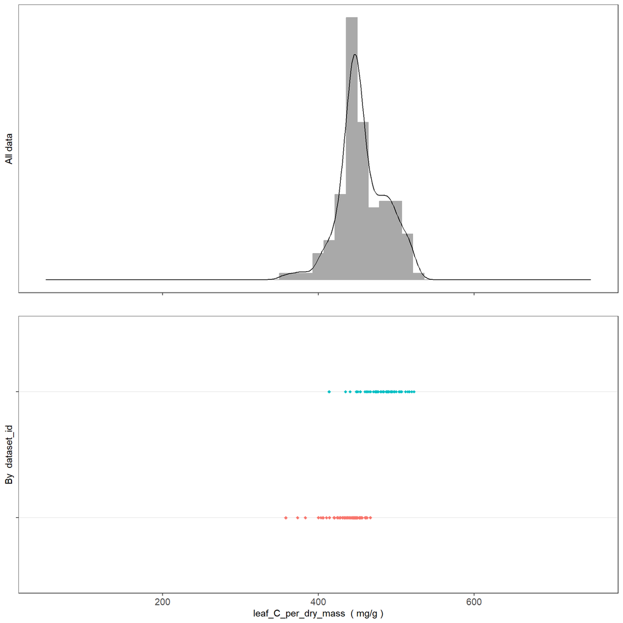

OUTLIERS: 4 of points in your dataset lie in either the bottom or top 2.5 percent of data

**Question:** (section `traits`) Do the data for the trait `leaf_C_per_dry_mass` appear correct?

### leaf_N_per_dry_mass

We aligned the contributed variable called `N (%)` in the data you supplied with the trait `leaf_N_per_dry_mass` in the AusTraits database, with value_types `raw`.

The original variable was supplied with units `%`; these were converted to our standard `mg/g`.

The data has the following properties:

- **standardised name**: leaf_N_per_dry_mass
- **standardised description**: The ratio [PATO:0001470] of the mass [PATO:0000125] of nitrogen [CHEBI:25555] in a leaf [PO:0025034] to leaf dry mass [TO:0001014].
- **label**: Leaf nitrogen (N) content per unit leaf dry mass
- **units**: mg/g
- **records**: 52 in this study (of 173 in AusTraits)
- **allowable range**: 0.5 - 100 mg/g
- **observed range in this study**: 10 - 24 mg/g

Data for this trait in this study were collected using the following methods:

- **value_type**: raw
- **replicates**: 1
- **methods**: During collection, care was taken to prevent moisture from affecting the collected material while in the field by placing samples in paper bags to air dry and storing them within a rain-proof container that was left open to the atmosphere to air-dry the leaf material as much as possible. Upon returning to the University of Adelaide, plant samples were transferred to a plant press and left to air dry for 3.5 months, while soil samples were oven-dried at 40 °C for 48 h. ^p After oven-drying, soil samples were ground and sieved to <2 mm. Plant material was subsampled from the plant press and oven-dried for 1 h at 60 °C before leaves were separated from twigs and branches and ground with a puck mill to a fine powder suitable for extraction and subsequent chemical analysis. Total N and C were measured by Dumas combustion by APAL (Australian Precision Ag Laboratory), Hindmarsh, SA, using an Elementar Variomax XN analyser with the combustion chamber at 900 °C and an oxygen flow rate of 125 mL min-1.

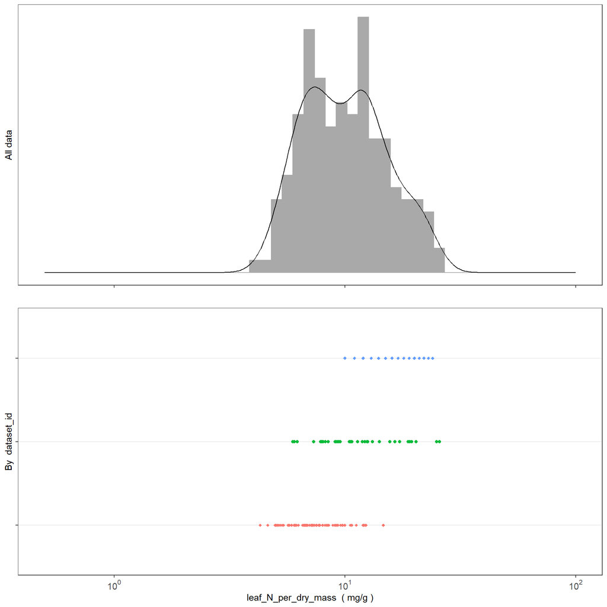

OUTLIERS: 3 of points in your dataset lie in either the bottom or top 2.5 percent of data

**Question:** (section `traits`) Do the data for the trait `leaf_N_per_dry_mass` appear correct?

### leaf_P_per_dry_mass

We aligned the contributed variable called `P (mg kg-1)` in the data you supplied with the trait `leaf_P_per_dry_mass` in the AusTraits database, with value_types `raw`.

The original variable was supplied with units `mg/kg`; these were converted to our standard `mg/g`.

The data has the following properties:

- **standardised name**: leaf_P_per_dry_mass
- **standardised description**: The ratio [PATO:0001470] of the mass [PATO:0000125] of phosphorus [CHEBI:28659] in a leaf [PO:0025034] to leaf dry mass [TO:0001014].
- **label**: Leaf phosphorus (P) content per unit leaf dry mass
- **units**: mg/g
- **records**: 53 in this study (of 174 in AusTraits)
- **allowable range**: 0.03 - 12 mg/g
- **observed range in this study**: 0.334 - 3.053 mg/g

Data for this trait in this study were collected using the following methods:

- **value_type**: raw
- **replicates**: 1
- **methods**: During collection, care was taken to prevent moisture from affecting the collected material while in the field by placing samples in paper bags to air dry and storing them within a rain-proof container that was left open to the atmosphere to air-dry the leaf material as much as possible. Upon returning to the University of Adelaide, plant samples were transferred to a plant press and left to air dry for 3.5 months, while soil samples were oven-dried at 40 °C for 48 h. ^p After oven-drying, soil samples were ground and sieved to <2 mm. Plant material was subsampled from the plant press and oven-dried for 1 h at 60 °C before leaves were separated from twigs and branches and ground with a puck mill to a fine powder suitable for extraction and subsequent chemical analysis. Total P concentrations in plant and soil samples were determined using the method of Zarcinas et al. (1996). In brief, for plant samples, dried and ground leaf biomass (0.25 g) was cold-digested overnight in a 2 mL 70% nitric acid and 0.5 mL 30% hydrogen peroxide mixture. For soils, samples (0.25 g) were cold-digested overnight in 4 mL of aqua regia (3:1 mixture of 37% hydrochloric acid and 70% nitric acid). The following day, the acid digests were heated to 125 °C for 3.5 h. The digests were allowed to cool, diluted to 20 mL through the addition of Milli-Q water, filtered with Whatman Grade 42, ashless filter paper and analysed by ICP-OES (Perkin Elmer Avio 200).

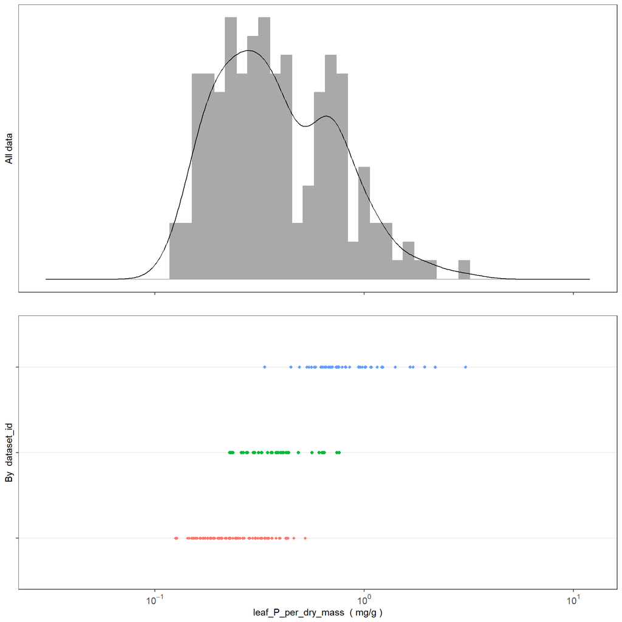

OUTLIERS: 5 of points in your dataset lie in either the bottom or top 2.5 percent of data

**Question:** (section `traits`) Do the data for the trait `leaf_P_per_dry_mass` appear correct?

## Categorical traits

No categorical traits data are currently available in this dataset.

# Taxon list

We have records on the following taxa from your study. We have attempted to align taxon names in this study with the Australian Plant Census (APC) or Australian Plant Names Index (APNI).

## Full taxa list

The table below shows the table of all taxa in this study, where possible using the name aligned with the APC. Columns are as follows:

| key | value |
| --- | --- |
| taxon_name | Scientific name of the taxon on which traits were sampled, without authorship. When possible, this is the currently accepted (botanical) or valid (zoological) scientific name, but might also be a high… |
| taxonomic_dataset | Name of the taxonomy (tree) that contains this concept. ie. APC, AusMoss etc. |
| taxon_rank | The taxonomic rank of the most specific name in the scientific name. |
| trinomial | The infraspecific taxon name match for an original name. This column is assigned `na` for taxon name that are at a broader taxonomic_resolution. |
| binomial | The species-level taxon name match for an original name. This column is assigned `na` for taxon name that are at a broader taxonomic_resolution. |
| genus | Genus of the taxon without authorship. |
| family | Family of the taxon. |
| taxon_distribution | Known distribution of the taxon, by Australian state. |
| establishment_means | Statement about whether an organism or organisms have been introduced to a given place and time through the direct or indirect activity of modern humans. |
| taxonomic_status | The status of the use of the scientificName as a label for the taxon in regard to the ‘accepted (or valid) taxonomy’. The assigned taxonomic status must be linked to a specific taxonomic reference tha… |
| taxon_id | An identifier for the set of taxon information (data associated with the taxon class). May be a global unique identifier or an identifier specific to the data set. Must be resolvable within this datas… |
| taxon_id_genus | An identifier for the set of taxon information (data associated with the taxon class) for the genus associated with a taxon name. May be a global unique identifier or an identifier specific to the dat… |
| taxon_id_family | An identifier for the set of taxon information (data associated with the taxon class) for the family associated with a taxon name. May be a global unique identifier or an identifier specific to the da… |
| scientific_name | The full scientific name, with authorship and date information if known. |
| scientific_name_id | An identifier for the set of taxon information (data associated with the taxon class). May be a global unique identifier or an identifier specific to the data set. Must be resolvable within this datas… |

Clicking on the name will take you to the relevant taxonomic record in the APC or APNI, where known:

| taxon_name | taxonomic_dataset | taxon_rank | trinomial | binomial | genus | family | taxon_distribution | establishment_means | taxonomic_status | taxon_id | taxon_id_genus | taxon_id_family | scientific_name | scientific_name_id |
| --- | --- | --- | --- | --- | --- | --- | --- | --- | --- | --- | --- | --- | --- | --- |
| [Acacia decora](https://id.biodiversity.org.au/taxon/apni/51285858) | APC | species |  | Acacia decora | Acacia | Fabaceae | Qld, NSW, Vic | native | accepted | https://id.biodiversity.org.au/taxon/apni/51285858 | https://id.biodiversity.org.au/taxon/apni/51471290 | https://id.biodiversity.org.au/taxon/apni/51702961 | Acacia decora Rchb. | https://id.biodiversity.org.au/name/apni/61446 |
| [Callitris glaucophylla](https://id.biodiversity.org.au/taxon/apni/51434202) | APC | species |  | Callitris glaucophylla | Callitris | Cupressaceae | WA, NT, SA, Qld, NSW, ACT, Vic (native and naturalised) | native and naturalised | accepted | https://id.biodiversity.org.au/taxon/apni/51434202 | https://id.biodiversity.org.au/taxon/apni/51687694 | https://id.biodiversity.org.au/taxon/apni/51687695 | Callitris glaucophylla Joy Thomps. & L.A.S.Johnson | https://id.biodiversity.org.au/name/apni/98291 |
| [Einadia nutans](https://id.biodiversity.org.au/node/apni/4346879) | APC | species |  | Einadia nutans | Einadia | Chenopodiaceae | WA, NT, SA, Qld, NSW, ACT, Vic, Tas | native | accepted | https://id.biodiversity.org.au/node/apni/4346879 | https://id.biodiversity.org.au/taxon/apni/51433168 | https://id.biodiversity.org.au/taxon/apni/51613011 | Einadia nutans (R.Br.) A.J.Scott | https://id.biodiversity.org.au/name/apni/71739 |
| [Eucalyptus blakelyi](https://id.biodiversity.org.au/node/apni/2914510) | APC | species |  | Eucalyptus blakelyi | Eucalyptus | Myrtaceae | Qld, NSW, ACT, Vic | native | accepted | https://id.biodiversity.org.au/node/apni/2914510 | https://id.biodiversity.org.au/taxon/apni/51738743 | https://id.biodiversity.org.au/taxon/apni/51738744 | Eucalyptus blakelyi Maiden | https://id.biodiversity.org.au/name/apni/59289 |
| [Eucalyptus camaldulensis](https://id.biodiversity.org.au/node/apni/2921040) | APC | species |  | Eucalyptus camaldulensis | Eucalyptus | Myrtaceae | WA (native and naturalised), NT, SA, Qld, NSW, ACT, Vic | native and naturalised | accepted | https://id.biodiversity.org.au/node/apni/2921040 | https://id.biodiversity.org.au/taxon/apni/51738743 | https://id.biodiversity.org.au/taxon/apni/51738744 | Eucalyptus camaldulensis Dehnh. | https://id.biodiversity.org.au/name/apni/94050 |
| [Eucalyptus microcarpa](https://id.biodiversity.org.au/node/apni/7646328) | APC | species |  | Eucalyptus microcarpa | Eucalyptus | Myrtaceae | SA, Qld, NSW, Vic | native | accepted | https://id.biodiversity.org.au/node/apni/7646328 | https://id.biodiversity.org.au/taxon/apni/51738743 | https://id.biodiversity.org.au/taxon/apni/51738744 | Eucalyptus microcarpa (Maiden) Maiden | https://id.biodiversity.org.au/name/apni/56305 |
| [Eucalyptus pauciflora](https://id.biodiversity.org.au/node/apni/2897845) | APC | species |  | Eucalyptus pauciflora | Eucalyptus | Myrtaceae | SA, Qld, NSW, ACT, Vic, Tas | native | accepted | https://id.biodiversity.org.au/node/apni/2897845 | https://id.biodiversity.org.au/taxon/apni/51738743 | https://id.biodiversity.org.au/taxon/apni/51738744 | Eucalyptus pauciflora Sieber ex Spreng. | https://id.biodiversity.org.au/name/apni/87566 |
| [Eucalyptus sideroxylon](https://id.biodiversity.org.au/taxon/apni/51440727) | APC | species |  | Eucalyptus sideroxylon | Eucalyptus | Myrtaceae | SA (doubtfully naturalised), Qld, NSW, Vic | native and naturalised | accepted | https://id.biodiversity.org.au/taxon/apni/51440727 | https://id.biodiversity.org.au/taxon/apni/51738743 | https://id.biodiversity.org.au/taxon/apni/51738744 | Eucalyptus sideroxylon A.Cunn. ex Woolls | https://id.biodiversity.org.au/name/apni/76926 |

To create the list of aligned taxa, we needed to make some taxonomic changes. This involved two stages.

- **Stage 1**: Where possible (i.e. there was no or only a few characters difference), the name you supplied was matched automatically with a known name in APC or APNI. In other cases we may have aligned the taxa by searching for an appropriate match. Such changes are documented in the study metadata file. The variable `aligned_name` shows the updated name. The variable `d1` shows the number of characters difference between the `original_name` and `aligned_name`.
- **Stage 2**: Once aligned with a known name, we used the APC to update the `aligned_name` to an accepted name. The taxonomic status of the aligned name is indicated in column `status aligned name`. If accepted, no change was made. If it is a synonym or otherwise, the name was changed according to the recommendation given in the APC. Where they existed, we preferred to take the accepted status of an `aligned_name`, if it existed. Alternative status values are indicated in brackets. This indicate if alternative uses of the name were ever applied.

Links on `aligned_name` and `taxon_name` take you to the APC or APNI record for that name.

| original_name | d1 | aligned_name | d2 | taxon_name | aligned_name_taxonomic_status |
| --- | --- | --- | --- | --- | --- |

## Unknown taxa

We were unable to find taxonomic matches for the following taxa in the data. Where genus and family are shown, the specified genus aligns with an accepted genus. The term `unplaced` appears as the `status` for names on the APNI list, but not yet reviewed by the APC.

| taxon_name | taxonomic_dataset | taxon_rank | trinomial | binomial | genus | family | taxonomic_status | taxon_id_genus | taxon_id_family | scientific_name |
| --- | --- | --- | --- | --- | --- | --- | --- | --- | --- | --- |

**Question:** (section `taxonomic_updates`) Do these taxonomic alignments and corrections look reasonable?

# Review of questions

Here is a summary of the questions we would like answers to. Clicking on the links will take you back to the appropriate spot in the document. Please copy and past these into an email when you respond.

# Session information

The technical information below may useful for us for the sake of reproducibility, but you don’t need to worry about it!

This report was generated using the data from the commit 01fff235d61098f29e5a17ec7a39b27bdfab15ab